# A3: Incarceration

### Introduction

An introduction of the problem domain and a description of the variable(s) you are choosing to analyze (and why!) *the problem domain is that I want to address : how jail population change overtime? how is discharge amount correlates with the population density? and what states are with the highest jail population rates and what are with the lowest? I think my work is very useful for studying the human geography and economies.*

### Summary Information

In my work, I include these 5 following data : The most popular state is CA, with a population of 39557045. The state with most whites in jail is WV, it is 93.8566572%. The state with most blacks in jail is DC, it is 85.9912748%. back in 2008, which is 10 years before the most recent data was collected, the state with most percent of population in jail is LA, the number is 0.675561%. For our state Washington, the jail population percentage was 0.206335% in 2008, and in 2018 the number was 0.1693961%; and decreases -17.9023782%.

### The Dataset

Who collected the data? *Vera Institute of Justice* How was the data collected or generated? *This work employed two Bureau of Justice Statistics (BJS) data collections: the Census of Jails (COJ), which covers all jails and is conducted every five to eight years since 1970, and the Annual Survey of Jails (ASJ), which covers about one-third of jails-and includes nearly all of the largest jails-that has been conducted in non-census years since 1982.* Why was the data collected? *county-level variability makes for more robust, theoretically-grounded studies of the high rates of incarceration seen across the United States* How many observations (rows) are in your data? *153811 rows* How many features (columns) are in the data? *121 columns* What, if any, ethical questions or questions of power do you need to consider when working with this data? *Because the associations that control the data are mostly white, it is impossible to know whether they will obscure white data and enhance data for people of color in order to maintain a positive image of white people.* What are possible limitations or problems with this data? (at least 200 words) *I think the overall data is comprehensive, however there are some flaws, because it only counted the number of prison, not the charges detailed classification, very bad for our study of the regional social unrest, for example, a prison criminals, the 100 shooting another prison 100 tax evasion of criminals, They are statistically the same, but the damage to society is different. This data table is also missing a lot of states with a small population, such as Delaware, which has a lot of NA values, which makes me make a lot of errors in the statistics; Besides this, I don’t think he did a good job of explaining the definition of commuter area and urban area, which caused me great inconvenience when studying the relationship between crime and geography.*

### Trends Over Time Chart

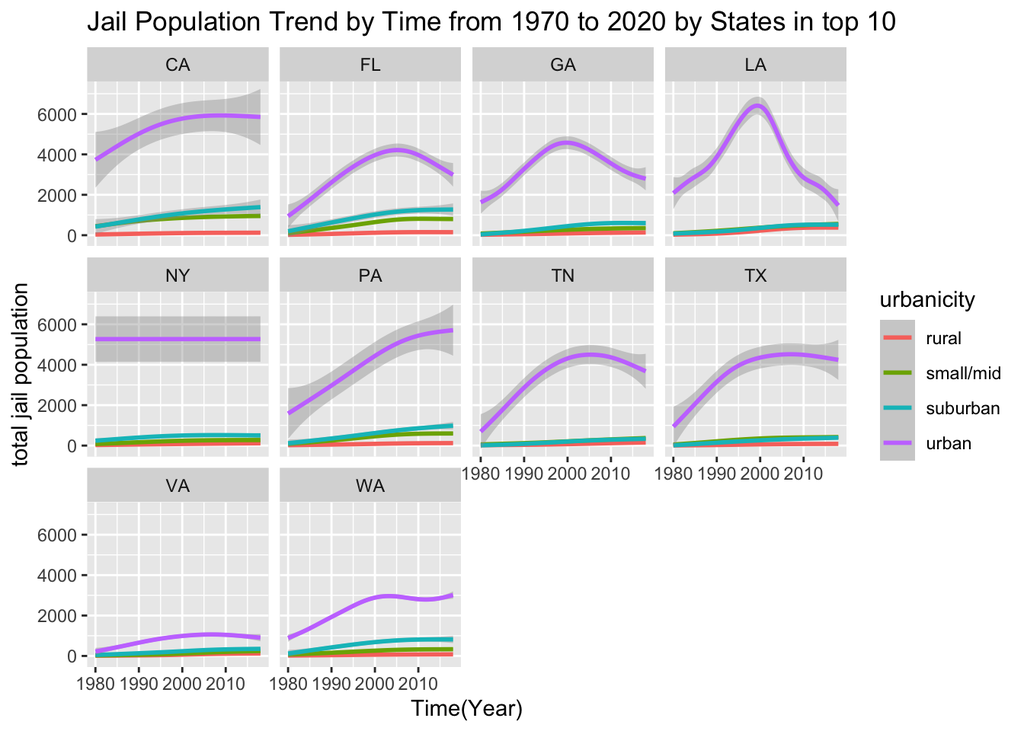

In my chart1, I creat a plot to indicate the trend of total jail population over time in top 10 most jail population states. From the plot, I can conclude that in the southern area, the jail population increases from 1980s and reached its peak at 2000s, and after that the jail population decreases which could be a good indicator of its ecomonic growth.

### Variable Comparison Chart

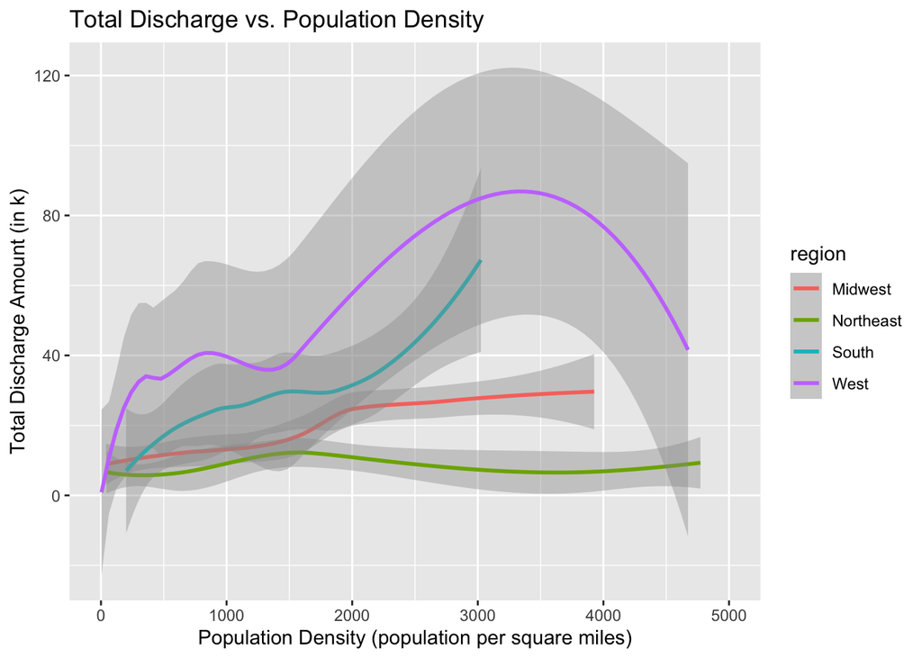

### Map

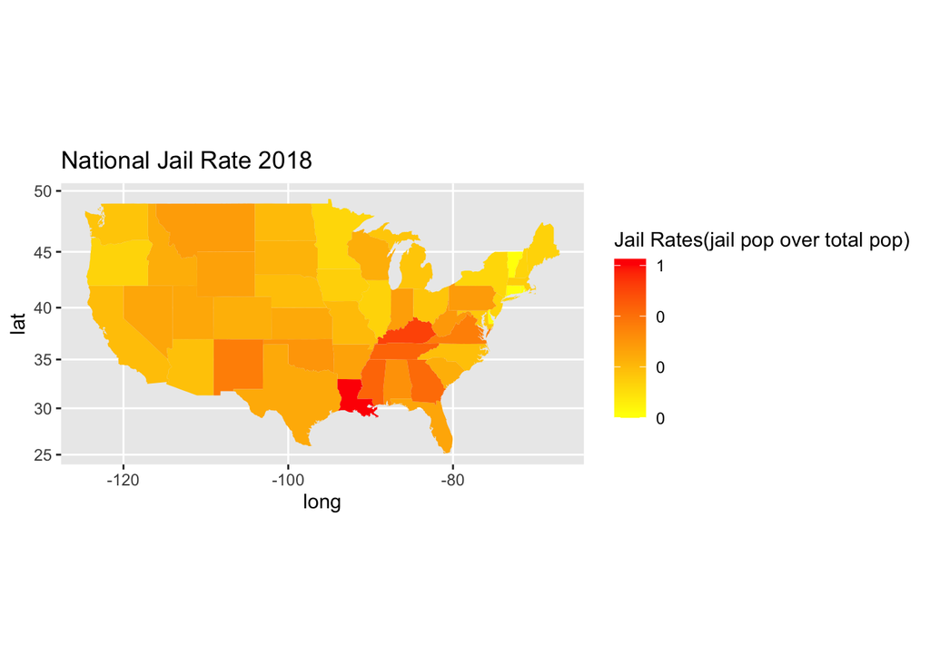

*In my chart 3, I create a map about the rate of jail population in each states. It is very useful to study on which states are the safest and which are the most dangerous. In my map, higher rate of jail population is indicated by red, and lower by yellow. We can conclude that the states with the most percent of jail population are Louisiana and Kentucky, the lowest are Vermont and Connecticut.*